# Curriculum vitae

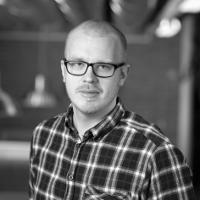

Johan Junkka

Centre for Demographic and  
Ageing Research  
Umeå University  
SE-901 87 Umeå, Sweden

+46 90 786 53 73  
johan.junkka@umu.se  
johanjunkka.com

Born: 1981, Malmberget, Sweden  
Nationality: Swedish

## Current position

**Associate Professor**, Centre for Demographic and Ageing Reserch, Umeå University, Sweden

## Research intersts

Historical demography; Social networks; Social capital; Population and climate; Disability studies

## Appointments

2020 - 2024

Assistant Professor, Centre for Demographic and Ageing Reserch, Umeå University, Sweden

2020 - 2020

Senior Research Assistant, Centre for Demographic and Ageing Reserch, Umeå University, Sweden

2018 - 2020

Postdoctoral fellow, Centre for Demographic and Ageing Reserch, Umeå University, Sweden

2012 - 2018

PhD student in History, Department of Historical, Philosophical and Religious studies, Umeå University, Sweden

## Education

2018

**PhD in History** Umeå university Sweden

2011

**Master in History** Umeå university Sweden

## Publications

### Books and articles

Vikström, H., Mårald, E., Junkka, J. (2025). Policy silences in Nordic-Arctic energy transitions: A topic-modelling study. *Energy policy*, *206*(114746). doi:10.1016/j.enpol.2025.114746

Junkka, J., Häggström Gunfridsson, E., Vikström, L. (2025). Decomposition of disability prevalences: Age and rate effects in northern Sweden, 1900–1950. *Historical Life Course Studies*. doi:10.51964/hlcs23094

Namatovu, F., Häggström Gunfridsson, E., Junkka, J., Vikström, L. (2025). The Dynamic Association between Disability and Parenthood in Sweden. In (Eds.), *Contemporary Perspectives in Family Research.* Emerald Publishing Limited. doi:10.1108/s1530-353520250000027006

Sundvall, S., Junkka, J. (2024). Better off in the city? Economic Outcomes of Rural Out-Migration in Sweden - Sibling Study of Cohorts 1960-1984. *Population, Space and Place*, *e2765*. doi:10.1002/psp.2765

Junkka, J., Hiltunen, M. (2024). Temperature- and seasonality-related infectious disease mortality among infants: A retrospective time-series study of Sweden, 1868–1892. *Vienna Yearbook of Population Research*, *22*. doi:10.1553/p-33g4-pgab

Vikström, L., Junkka, J., Karhina, K. (2023). Two Centuries of Disability Disadvantages in Swedish Partnerships. *Disability & Society*. doi:10.1080/09687599.2022.2160924

Erkisson, L., Junkka, J., Sandström, G., Vikström, L. (2022). Supply or demand?: Institutionalization of the mentally ill in the emerging Swedish welfare state, 1900–1959. *History of Psychiatry*, *33*(2). doi:10.1177/0957154X221084976

Vikström, L., Karhina, K., Junkka, J. (2022). Two Centuries of Inequalities: Disability and Partnership in Sweden. In Nico, M, Pollock, G (Eds.), *The Routledge Handbook of Contemporary Inequalities and the Life Course.* Routledge: New York doi:10.4324/9780429470059-14

Karlsson, L., Junkka, J., Lundevaller, E., Schumann, B. (2021). Ambient temperature and stillbirth risks in northern Sweden, 1880-1950. *Environmental epidemiology*, *5*(6). doi:10.1097/EE9.0000000000000176

Karlsson, L., Junkka, J., Schumann, B., Lundevaller, E. (2021). Socioeconomic disparities in climate vulnerability: neonatal mortality in northern Sweden, 1880–1950. *Population and environment*. doi:10.1007/s11111-021-00383-9

Junkka, J., Karlsson, L., Lundevaller, E., Schumann, B. (2021). Climate vulnerability of Swedish newborns: gender differences and time trends of temperature-related neonatal mortality, 1880 – 1950. *Environmental research*, *192*. doi:10.1016/j.envres.2020.110400

Junkka, J., Sandström, G., Vikström, L. (2020). The emergence of social gaps in mental health: A longitudinal population study in Sweden, 1900-1959. *PLOS ONE*, *15*(4). doi:10.1371/journal.pone.0232462

Junkka, J. (2019). Spatial diffusion of fertility decline in northern Sweden, 1850-1950. *Annales de Démographie Historique*, *138*(2). doi:10.3917/adh.138.0083

Vikström, L., Häggström Lundevaller, E., Junkka, J., Haage, H. (2019). Ett annorlunda liv? Följder av funktionsnedsättningar i 1800-talets Sverige. *Funktionsnedsättning i arbetsliv och välfärd, Försäkringskassan, Analys och prognos*. https://www.forsakringskassan.se/wps/wcm/connect/fac0708f-cade-48e1-9a03-df7e59d0407a/socialforsakringsrapport-2019-1.pdf?MOD=AJPERES&CVID=

Junkka, J. (2018). Membership in and Presence of Voluntary Organisations during the Swedish Fertility Transition, 1880-1949. *Historical Life Course Studies*, *5*. doi:10.51964/hlcs9335

Junkka, J. (2018). *Shared practices. Social networks and fertility decline during the Swedish demographic transition, 1850-1950*. Umeå University: Umeå http://urn.kb.se/resolve?urn=urn:nbn:se:umu:diva-147281

Junkka, J. (2018). Voluntary associations and net fertility during the Swedish demographic transition. *European Journal of Population*, *34*(5). doi:10.1007/s10680-018-9465-5

Junkka, J., Edvinsson, S. (2016). Gender and fertility within the free churches in the Sundsvall region, Sweden, 1860-1921. *The History of the Family*, *21*(2). doi:10.1080/1081602X.2015.1043929 http://umu.diva-portal.org/smash/get/diva2:823430/FULLTEXT01.pdf

### Working papers

Junkka, J., Vikström, L., Lundevaller, E. (2021). Healthy migrant perspectives on disability and mobility in a nineteenth-century population. *CEDAR working papers*, *19*. http://urn.kb.se/resolve?urn=urn%3Anbn%3Ase%3Aumu%3Adiva-186973

Vikström, L., Junkka, J., Famatovu, N., Lundevaller, E. (2021). A longitudinal study of how disability affects mortality in Swedish Populations from the 1800s, 1900s and 2000s. *CEDAR working papers*, *18*. http://urn.kb.se/resolve?urn=urn%3Anbn%3Ase%3Aumu%3Adiva-186866

### Software

Junkka, J. (2022). *leafletwrapper - Wrapper for the leaflet package, to simplify interactive visualisations*. https://github.com/junkka/leafletwrapper

Junkka, J. (2022). *histmaps - A R data package of Swedish historical administrative boundaries for parishes and counties 1634-1990. Version 0.3.1.9999*. https://github.com/junkka/histmaps

Junkka, J. (2021). *ehahleper - A R helper package for event history analysis*. https://github.com/junkka/ehahelper

Junkka, J. (2019). *db2connect - Connect to IBM DB2 servers*. https://github.com/junkka/db2connect

Junkka, J. (2017). *movement - Popular movement data for Sweden 1881-1950.*. https://github.com/junkka/movement

Junkka, J. (2015). *hisco - A R package for classification of HISCO codes to HISCLASS, SOCPO and HISCAM social class systems*. https://github.com/cedarfoundation/hisco

## Conferences & Invited presentations

June 2025

"Policytystnader i den Nordisk-Arktiska omställningen till förnyelsebar energi" *AI Forum, Skellefteå kraft* Skellefteå, Sweden.

May 2025

"Disability and fertility in Sweden across two centuries" *Nordic Netword on Disability Research Conference* Helsinki, Finland.

June 2023

"Life and Death Behind Asylum Walls: An Investigation of Mortality among Institutionalized Individuals, 1900-1960" *Svenska historikermötet 2023* Umeå, Sweden.

April 2023

"Discussant for the session: Social and Cultural Determinants of Infant Mortality in the Past: New Insights from across Europe" *European social science history conference* Gothernburg, Sweden.

January 2023

"Temperature and Seasonality Related Infectious Disease Mortality Among Infants. A Retrospective Time-Series Study of Sweden, 1868-1892" *Wittgenstein Centre Online Colloquium* Wittgenstein Centre, Vienna, Austria.

January 2023

"Temperature and Seasonality Related Infectious Disease Mortality Among Infants. A Retrospective Time-Series Study of Sweden, 1868-1892" *Wittgenstein Centre Online Colloquium* Wittgenstein Centre, Vienna, Austria.

December 2022

"Temperature and Seasonality Related Infectious Disease Mortality Among Infants. A Retrospective Time-Series Study of Sweden, 1868-1892" *Population and Climate Change: The Defining Relationship of the 21st Century* Wittgenstein Centre, Vienna, Austria.

November 2022

"A longitudinal study of how disability has affected survival in Swedish populations across 150 years" *European Public Health Conference* Berlin, Germany.

November 2022

"Temperature related infectious disease mortality among infants and seasonality in Sweden, 1868-1892" *European Public Health Conference* Berlin, Germany.

October 2022

"Temperature and seasonality related infectious disease mortality among infants. A retrospective time-series study of Sweden, 1868-1892" *CED seminar* Lund, Sweden.

June 2022

"Cause Specific Infant Mortality and Ambient Temperature in Northern Sweden 1860-1892" *European Population Conference* Groningen, The Netherlands.

March 2022

"A longitudinal study of how disability affects mortality in Swedish Populations from the 1800s, 1900´s and 2000´s" *Conference of the European Society of Historical Demography* Madrid, Spain.

March 2022

"Cause specific infant mortality and ambient temperature in Northern Sweden 1868-1892" *Conference of the European Society of Historical Demography* Madrid, Spain.

December 2021

"Measuring mortality responses to temperature exposures using distributed lag non-linear models" *Workshop - SHiP: Comparative perspectives on health and disease in port cities* Online.

November 2021

"Religious differences in cause-specific post-perinatal mortality: A sibling study of Sweden, 1860-1892" *The Social Science History Associations 2021 Annual Meeting* Online.

October 2021

"Religious differences in cause-specific infant mortality in northern Sweden, 1860-1900" *CEDAR seminars* Online.

September 2021

"Religious differences in cause-specific infant mortality in northern Sweden, 1860-1900" *The European Association for the History of Medicine and Health Biennial Conference* Online.

March 2021

"Long-term Trends of Mental Impairment and Institutionalization in the Early Swedish Welfare State (1900–1960)" *European Social Science History Conference* Online.

May 2020

"The emergence of social gaps in mental health: A longitudinal population study in Sweden, 1900-1959" *CEDAR seminars* Center for Demographic and Ageing Research, Umeå university, Sweden.

Februari 2020

"Healthy migrant perspectives on disability and mobility in a 19th-century population" *Seminar* Department of Geography, Umeå University, Sweden.

November 2019

"Voluntary association growth and mortality in Sweden 1895-1930" *CEDAR seminars* Center for Demographic and Ageing Research, Umeå university, Sweden.

October 2019

"Sociala nätverk och demografisk förändring: Den svenska folkrörelsen 1880-1950" *Demografiska Databasens Webinarium* Center for Demographic and Ageing Research, Umeå university, Sweden.

October 2019

"Healthy migrant perspectives on disability and mobility among men and women in a 19th-century population" *Multidisciplinary Perspectives on Gender Gaps in Health* Max Planck Institute for Demographic Research, Villa Vigoni, Italy.

October 2019

"Poster presentation: Gender and socioeconomic gaps in mental health: Long-term trends in psychiatric impairment and institutionalisation in Sweden, 1900-1960" *Multidisciplinary Perspectives on Gender Gaps in Health* Max Planck Institute for Demographic Research, Villa Vigoni, Italy.

June 2019

"Spatial diffusion of fertility decline in northern Sweden, 1850-1950" *Nordic Demographic Symposium* Reykjavík, Iceland.

May 2019

"Mental Disabilities and Institutionalisation in the Early Swedish Welfare State" *Svenska historikermötet 2019* Växjö, Sweden.

January 2019

"Healthy migrant perspectives on disability and mobility" *CEDAR seminars* Center for Demographic and Ageing Research, Umeå university, Sweden.

December 2017

"Topic and trends in fertility transitions research, 1950-2014: A LDA analysis of a 5,927 scientific documents" *FADC Annual Conference 2017* HUMLabX, Umeå university, Sweden.

November 2016

"Topics and trends in 50 years of fertility transition research. A LDA analysis of a large collection of abstracts" *Historisk demografi - dåtid, nutid och framtid* Center for Demographic and Ageing Research, Umeå university, Sweden.

September 2016

"Shared practices: Class, Community, and Fertility in Skellefteå Region, 1850-1950" *European Society of Historical Demography Conference* Leuven, Belgium.

May 2016

"Shared practices: Class, Community, and Fertility in Skellefteå Region, 1850-1950" *Population Dynamics and Public Policy workshop* Brussels, Belgium.

May 2016

"Shared Practices" *Higher Seminar in History* Department of Historical, Philosophical and Religious Studies, Umeå university, Sweden.

May 2016

"Shared Practices: The Influence of Social Networks on Fertility during the Demographic Transition" *Family Research at Umeå University* Department of Historical, Philosophical and Religious Studies, Umeå university, Sweden.

April 2016

"Shared practices: Class, Community, and Fertility in Skellefteå Region, 1850-1950" *CEDAR seminars* Center for Demographic and Ageing Research, Umeå university, Sweden.

April 2016

"Voluntary associations and fertility during the Swedish demographic transition" *European Social Science History Conference* Valencia, Spain.

October 2015

"Popular movements and net fertility during the Swedish fertility transition, 1890-1900" *Higher Seminar in Economic history* Department of Geography and Economic History, Umeå University, Sweden.

May 2015

"The popular movements and reproductive practices during the Swedish fertility decline 1890-1930" *Higher Seminar in History* Department of Historical, Philospical and Religious Studies, Umeå University, Sweden.

April 2015

"Starting with Git" *CEDAR Fertility Group Meeting* Centre for Demographic and Ageing Research, Umeå University, Sweden.

Februari 2015

"Sekularisering, genus och fertilitetsnedgång i Sverige 1890-1930" *Demografiska Databasens Webinarium* Demographic database, Umeå University, Sweden.

September 2014

"Freedom to Control? Gender and Fertility within the Free-Churches in Sundsvall, 1860-1921" *Conference of the European Society of Historical Demography* Alghero, Italy.

May 2014

"Freedom to Control? Gender and Fertility within the Free-Churches in Northern Sweden, 1860-1921" *Population Dynamics and Public Policy workshop* Evian, France.

November 2013

"Gender and Fertility Within the Free-Churches in Northern Sweden 1860-1920" *38th Annual Meeting of the Social Science History Association* Chicago, USA.

November 2012

"Secularization, gender and fertility change in northern Sweden 1870-1950, a research proposal" *Centre for Population Studies Seminar Series* Umeå University, Sweden.

## Workshops & Post-graduate courses

October-November 2013

"Variations in demographic outcome: The importance of gender, family and regions" University of Gothenburg

July-August 2013

"Longitudinal Analysis of Historical Demographic Data" ICPSR, University of Michigan, Ann Arbor MI, USA

## Commissions of trust

Peer-reviewer for:, Geografiska Annaler: Series B, Human Geography, Statistics, Historical methods, Vienna Yearbook of Population Research, American Journal of Epidemiology, Environmental Advances, Population Studies, History of the Family, SN Social Sciences, Biology of Sex Differences, Social History of Medicine, Journal of Migration History, Acta Obstetricia et Gynecologica Scandinavica, Historical Life Course Studies, Continuity and Change, Revista de Demografía História - Journal of Iberoamerican Population Studies.

Other commissions of trust, reviewer of project application for Czech Science Foundation, reviewer for Kriterium published anthology, jury member for the Swedish National Demographic Assocation’s thesis competition

2020-

Editor of CEDAR Working papers, Umeå Univeristy https://www.umu.se/en/centre-for-demographic-and-ageing-research/research/working-paper-series/

2020-

Co-supervisor of PhD student, History, Umeå univsersity

2022-

Co-supervisor of PhD student, Economic history, Umeå univsersity

2024-

Co-supervisor of PhD student, Economic history, Umeå univsersity

2016 - 2017

Board member of the Swedish Demographic Association (Svensk Demografisk Förening), http://demografi.se/

2012 - 2017

Member of the Arcum board (the Arctic Research Centre),, Umeå university, Sweden https://www.umu.se/en/arctic-research-centre/

2015

Chair of the Department of Historical, Philosophical and Religious Studies Doctoral council,, Umeå university, Sweden

## Teaching

2023-2024

Coordinator, lecturer and examiner on “Longitudinal Studies of Population Data”, Master course, CEDAR, Umeå University, Sweden

2021-2025

Applied quantitative and empirically driven gender research, PhD course, UCGS, Umeå University, Sweden

2023

Lecturer and examiner on Population studies, PhD course in History, Umeå University, Sweden.

2017-2024

Advisor and examiner for undergraduate theses in History, Umeå University, Sweden

2020-2021

Lecturer and examiner on “Population studies and societal challenges”, PhD course, Umeå University, Sweden

2020

Coordinator, lecturer and examiner for the “Historical demography” module within the mastersprogram in history, Umeå University, Sweden. https://www.umu.se/en/education/syllabus/1hi058/

2018

Lecturer and examiner on “Population studies and societal challenges”, master level course, Umeå University, Sweden

2015

Lecturer on “Using R at cedaR”, internal course at the Centre for Demographic and Ageing Research, Umeå University, Sweden. https://github.com/cedarfoundation/cedar_dplyr

2015

Lecturer on “Demography and Event History Analysis using R”, PhD course, EHPS-Net program, Umeå University, Sweden

2013

Teachers assistant on “Demokrati, individ och samhälle”, teachers program, Teachers education, Umeå University, Sweden

## Affiliations

European Association for the History of Medicine and Health, International

Social Science History Association, International

Swedish Demographic Association, National, Sweden

Arctic Research Centre at Umeå University (Arcum), Umeå university, Sweden

## Grants & Awards

2022

Wittgenstein Centre for Demography and Global Human Capital, Poster Award.

2019

Wallenberg Foundation, Travel grant. 12,000 SEK

2019

Stiftelsen J C Kempes Minnes Akademiska fonder, Travel grant. 5,000 SEK

2013

Svensk Nationel Datatjänst, Travel grant. 15,000 SEK

## Language skills

Languages

Swedish (native)

English (fluent)

Meänkieli (basic)

Programming

R (experienced)

SQL (experienced)

PHP (basic)

JavaScript (basic)

Python (basic)

PDF

[Source on GitHub](https://github.com/junkka/cv)

Last updated: September 23, 2025